# Analyse des donneés sur les activités sportives

Hamdi Bahloul—Amir Karouia

### Questionnaire :

Dans le cadre d’etude des preferences des gens dans le domaine sportive en generale et afin d’analyser leurs avis vis a vis le sport , on a lance un questionnaire compose de 20 questions pour obtenir a la fin une base de donnee constitue de 99 lignes et 43 colonnes. Parmi les variables , 30 sont quantitatives et les restes sont qualitatives.

### Objectif de l’ACP:

Pour notre etude , l’ACP permet de resumer le jeu de donnee et de reduire sa dimentionalite. Etude des individus: des individus ont les preference sont similaires , d’ou on essaye de regrouper les individus qui ont le meme caractere sportive et on detecte ceux qui sont exceptionnels.

Etude des variables (les preferences): l’ACP permet d’analyser la liaisons entre les variables et essaye de creer de nouvelles variables synthetique qui decrivent les profils des individus. Liens entre les deux etudes: Peut-on caracteriser des groupes d’individus par des variables ’.

### Installation des librairies necessaire:

```r
library(FactoMineR)

library(factoextra)
```

### Importation de la table :

```r
data=read.csv("C:/Users/hamdi/Desktop/Analyse des donnees/Sportscsv00.csv")
```

# Etude descriptive de quelques variables et representations graphiques:

```r
library(tidyverse)
```

1-Selection des variables quantitatives:

```r
tab<-data[,c(9,10,14,15,16,17,18,19,20,21,22,23,24,25,26,27,30,31,32,33,34,35,
           36,37,38,39,40,41,42,43)]
str(tab)
```

```
## 'data.frame':  99 obs. of  30 variables:
##  $ Conditions                        : int  3 1 3 2 2 3 3 3 1 3 ...
##  $ Matériaux                         : int  4 1 3 2 4 3 3 3 1 2 ...
##  $ Le.plaisir                        : int  3 4 2 4 4 4 4 2 1 4 ...
##  $ Defoulement                       : int  4 4 4 3 4 4 2 4 1 4 ...
##  $ Entretenir.le.corps               : int  4 3 4 3 4 2 4 3 2 4 ...
##  $ Prendre.la.masse.musculaire       : int  4 2 2 2 4 1 4 3 2 4 ...
##  $ Perdre.le.poids                   : int  1 3 1 3 1 1 2 1 1 3 ...
##  $ Avoir.une.bonne.condition.physique: int  4 2 4 4 4 2 4 3 2 4 ...
##  $ Avoir.plus.d.energie              : int  3 2 2 4 4 2 4 3 1 3 ...
##  $ Rencontrer.de.nouvelles.personnes : int  1 1 2 4 3 2 4 3 1 2 ...
##  $ Equilibre.de.vie                  : int  4 3 3 3 4 3 3 3 1 3 ...
##  $ Mental.clair.et.serein            : int  4 3 4 3 4 4 4 4 1 3 ...
##  $ Developper.la.souplesse           : int  1 2 2 2 4 3 4 3 1 3 ...
##  $ Réduire.le.stress                 : int  4 4 4 4 4 4 4 4 1 4 ...
```

[output cut: 16 more lines]

```r
summary(tab)
```

```
##    Conditions     Matériaux   Le.plaisir     Defoulement    Entretenir.le.corps
##  Min.   :0.00   Min.   :0   Min.   :0.000   Min.   :0.000   Min.   :0.000
##  1st Qu.:0.00   1st Qu.:0   1st Qu.:2.000   1st Qu.:2.000   1st Qu.:2.000
##  Median :2.00   Median :2   Median :3.000   Median :4.000   Median :3.000
##  Mean   :1.96   Mean   :2   Mean   :2.899   Mean   :3.141   Mean   :2.929
##  3rd Qu.:3.00   3rd Qu.:3   3rd Qu.:4.000   3rd Qu.:5.000   3rd Qu.:4.000
##  Max.   :5.00   Max.   :5   Max.   :5.000   Max.   :5.000   Max.   :5.000
##  Prendre.la.masse.musculaire Perdre.le.poids Avoir.une.bonne.condition.physique
##  Min.   :0.000               Min.   :0.000   Min.   :0.000
##  1st Qu.:1.000               1st Qu.:1.000   1st Qu.:2.000
##  Median :2.000               Median :2.000   Median :4.000
##  Mean   :2.323               Mean   :2.212   Mean   :3.081
##  3rd Qu.:4.000               3rd Qu.:4.000   3rd Qu.:4.000
##  Max.   :5.000               Max.   :5.000   Max.   :5.000
##  Avoir.plus.d.energie Rencontrer.de.nouvelles.personnes Equilibre.de.vie
##  Min.   :0.00         Min.   :0.000                     Min.   :0.000
##  1st Qu.:2.00         1st Qu.:1.000                     1st Qu.:2.000
##  Median :3.00         Median :2.000                     Median :3.000
##  Mean   :3.03         Mean   :2.061                     Mean   :2.747
##  3rd Qu.:4.00         3rd Qu.:3.000                     3rd Qu.:4.000
##  Max.   :5.00         Max.   :5.000                     Max.   :5.000
##  Mental.clair.et.serein Developper.la.souplesse Réduire.le.stress
##  Min.   :0.000          Min.   :0.000           Min.   :0.000
##  1st Qu.:2.000          1st Qu.:1.000           1st Qu.:3.000
##  Median :3.000          Median :2.000           Median :4.000
##  Mean   :2.879          Mean   :2.273           Mean   :3.232
##  3rd Qu.:4.000          3rd Qu.:3.000           3rd Qu.:4.000
##  Max.   :5.000          Max.   :5.000           Max.   :5.000
##  Eviter.la.routine   Confiance     Investissement      Seul
##  Min.   :0.000     Min.   :0.000   Min.   :1.00   Min.   :0.000
##  1st Qu.:2.000     1st Qu.:1.000   1st Qu.:2.00   1st Qu.:1.000
##  Median :4.000     Median :3.000   Median :3.00   Median :2.000
##  Mean   :3.081     Mean   :2.525   Mean   :2.97   Mean   :2.131
##  3rd Qu.:4.000     3rd Qu.:4.000   3rd Qu.:4.00   3rd Qu.:3.500
##  Max.   :5.000     Max.   :5.000   Max.   :5.00   Max.   :5.000
##  Avec.un.e..ami. Avec.un.e..coupin. Avec.la.famille Avec.une.équipe.sportive
##  Min.   :0.000   Min.   :0.000      Min.   :0.000   Min.   :0.000
##  1st Qu.:1.500   1st Qu.:1.000      1st Qu.:1.000   1st Qu.:1.000
##  Median :3.000   Median :3.000      Median :2.000   Median :3.000
##  Mean   :2.899   Mean   :2.455      Mean   :1.939   Mean   :2.667
##  3rd Qu.:4.000   3rd Qu.:4.000      3rd Qu.:3.000   3rd Qu.:4.000
##  Max.   :5.000   Max.   :5.000      Max.   :5.000   Max.   :5.000
##  Coach.professionel Musique.a.haute.volume.  Spectateurs     En.plein.air
##  Min.   :0.000      Min.   :0.000           Min.   :0.000   Min.   :0.000
##  1st Qu.:1.000      1st Qu.:1.000           1st Qu.:1.000   1st Qu.:2.000
##  Median :2.000      Median :3.000           Median :1.000   Median :3.000
##  Mean   :2.485      Mean   :2.758           Mean   :1.465   Mean   :2.919
##  3rd Qu.:4.000      3rd Qu.:4.000           3rd Qu.:2.000   3rd Qu.:4.000
##  Max.   :5.000      Max.   :5.000           Max.   :5.000   Max.   :5.000
##    Repas.sain        Dormir      Vaccin.naturel  sport.indispensable
##  Min.   :1.000   Min.   :1.000   Min.   :0.000   Min.   :1.000
##  1st Qu.:2.000   1st Qu.:3.000   1st Qu.:3.000   1st Qu.:3.000
##  Median :3.000   Median :4.000   Median :4.000   Median :4.000
##  Mean   :3.051   Mean   :3.727   Mean   :3.717   Mean   :3.687
##  3rd Qu.:4.000   3rd Qu.:5.000   3rd Qu.:5.000   3rd Qu.:5.000
##  Max.   :4.000   Max.   :5.000   Max.   :5.000   Max.   :5.000
```

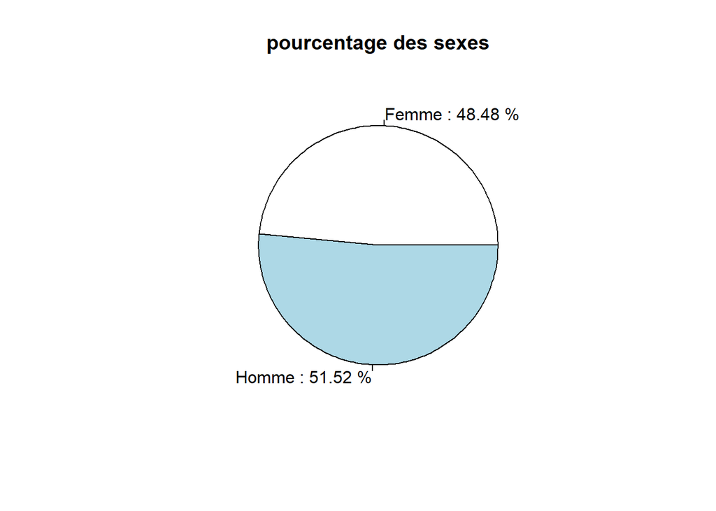

```r
n<-levels(as.factor(data$Sexe))
donnee<-table(data$Sexe)
pourcentage<-round(prop.table(donnee)*100,2)
pie(donnee, labels=c(paste(n[1],':',pourcentage[1],"%")
                     , paste(n[2],':',pourcentage[2],"%")),
    main = "pourcentage des sexes")
```

La moitié des répondants sont des femmes et l’autre ’ moitié sont des hommes.

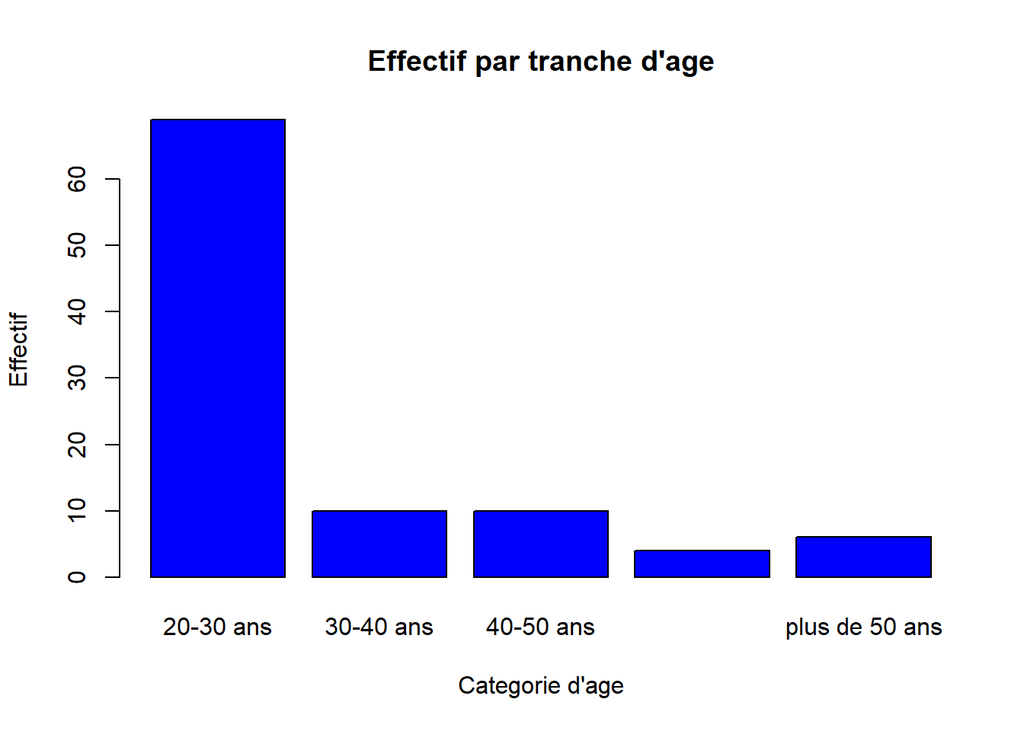

```r
plot(as.factor(data$CA),col="blue",
     xlab="Categorie d'age",ylab="Effectif",main="Effectif par tranche d'age")
```

La tranche d’age la plus présente dans nos projets est celle de 20 a 30 ans ’

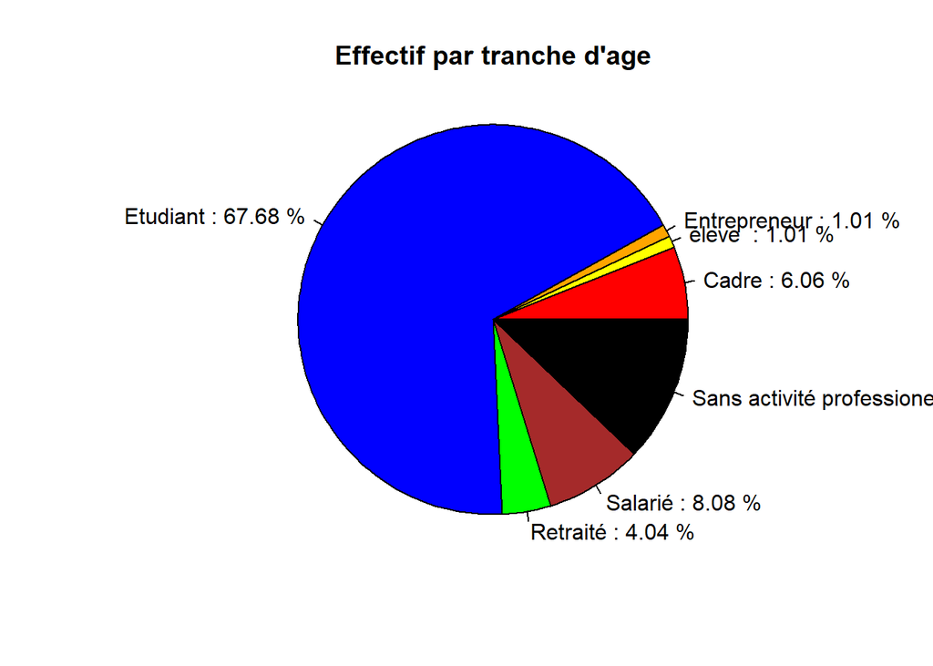

```r
nom<-levels(as.factor(data$CSP))
donne<-table(data$CSP)
pour<-round(prop.table(donne)*100,2)
pie(donne,labels=c(paste(nom[1],":",pour[1],"%"),paste(nom[2],":",
                  pour[2],"%"),paste(nom[3],":",pour[3],"%"),
                  paste(nom[4],":",pour[4],"%"),paste(nom[5],":",
                  pour[5],"%"),paste(nom[6],":",pour[6],"%"),
                  paste(nom[7],":",pour[7],"%")),radius = 1,
    col = c("red","yellow","orange","blue","green","brown","black"),main="Effectif par tranche d'age")
```

La catégorie socio-professionnelle dominante est celle des étudiants de 67.68% puis ceux qui n’ont pas d’activités professionnelle et puis les salarié et les cadres .

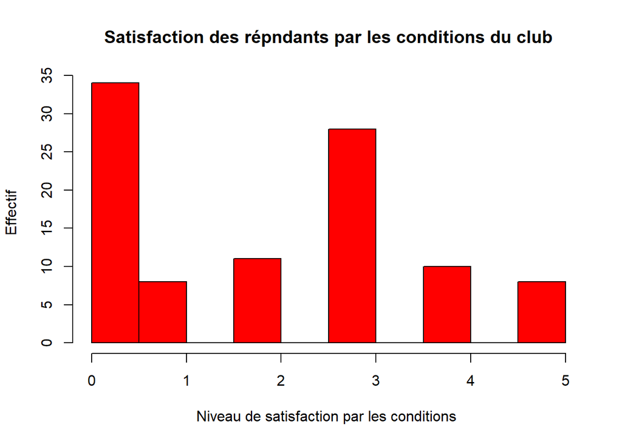

```r
hist(tab$Conditions,xlab = "Niveau de satisfaction par les conditions ",
     ylab = "Effectif",main = "Satisfaction des répndants par les conditions du club",
     col = "red")
```

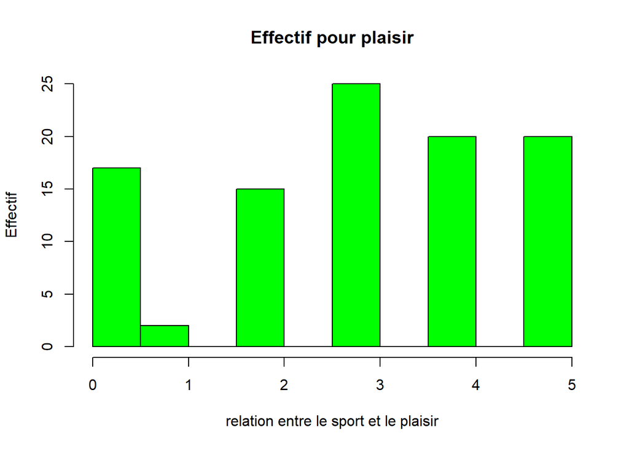

```r
hist(tab$Le.plaisir,xlab = "relation entre le sport et le plaisir",ylab = "Effectif",
     main = "Effectif pour plaisir",col = "green")
```

La majorité pratique le sport pour le plaisir.

### Pertinence de l’ACP:

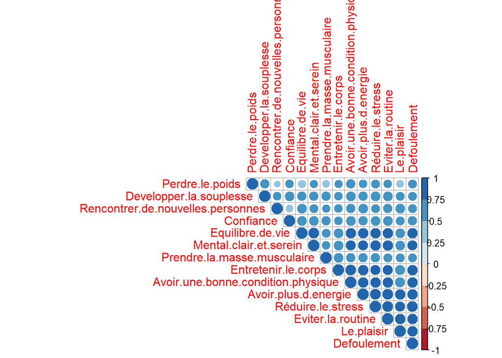

```r
library(corrplot)
bienfaits<-data[,c(14,15,16,17,18,19,20,21,22,23,24,25,26,27)]
X1<-as.matrix(bienfaits)
M1<-cor(X1)
library(RColorBrewer)
corrplot(M1, type="upper", order="hclust",
         col=brewer.pal(n=8, name="RdBu"))
```

Il y’a pas mal des variables qui sont corrlées positivement entre eux ce qui rend notre ACP pertinente.

# Analyse des composantes principales sur les bienfaits de pratiquer du sport :

### 1-Centrer et réduire la matrice X:

```r
X=as.matrix(bienfaits)
g=colMeans(X)
g
```

```
##                         Le.plaisir                        Defoulement
##                           2.898990                           3.141414
##                Entretenir.le.corps        Prendre.la.masse.musculaire
##                           2.929293                           2.323232
##                    Perdre.le.poids Avoir.une.bonne.condition.physique
##                           2.212121                           3.080808
##               Avoir.plus.d.energie  Rencontrer.de.nouvelles.personnes
##                           3.030303                           2.060606
##                   Equilibre.de.vie             Mental.clair.et.serein
##                           2.747475                           2.878788
##            Developper.la.souplesse                  Réduire.le.stress
##                           2.272727                           3.232323
##                  Eviter.la.routine                          Confiance
##                           3.080808                           2.525253
```

```r
Y=sweep(x = X,2,g,FUN = '-')
round(colMeans(X),3)
```

```
##                         Le.plaisir                        Defoulement
##                              2.899                              3.141
##                Entretenir.le.corps        Prendre.la.masse.musculaire
##                              2.929                              2.323
##                    Perdre.le.poids Avoir.une.bonne.condition.physique
##                              2.212                              3.081
##               Avoir.plus.d.energie  Rencontrer.de.nouvelles.personnes
##                              3.030                              2.061
##                   Equilibre.de.vie             Mental.clair.et.serein
##                              2.747                              2.879
##            Developper.la.souplesse                  Réduire.le.stress
##                              2.273                              3.232
##                  Eviter.la.routine                          Confiance
##                              3.081                              2.525
```

### 2-Calculer l’ecart type pour réduire les variables:

```r
n=nrow(X)
p=ncol(X)
et=apply(Y,2,function(x) sqrt(sum(x^2)/n))
et
```

```
##                         Le.plaisir                        Defoulement
##                           1.666636                           1.723340
##                Entretenir.le.corps        Prendre.la.masse.musculaire
##                           1.701173                           1.638109
##                    Perdre.le.poids Avoir.une.bonne.condition.physique
##                           1.665289                           1.618559
##               Avoir.plus.d.energie  Rencontrer.de.nouvelles.personnes
##                           1.623405                           1.441227
##                   Equilibre.de.vie             Mental.clair.et.serein
##                           1.572127                           1.653113
##            Developper.la.souplesse                  Réduire.le.stress
##                           1.420045                           1.692695
##                  Eviter.la.routine                          Confiance
##                           1.691791                           1.603931
```

### 3-Calculer la matrice centrée réduite Z:

```r
Z=sweep(x = Y,2,et,FUN = '/')
colSums(Z^2)/n
```

```
##                         Le.plaisir                        Defoulement
##                                  1                                  1
##                Entretenir.le.corps        Prendre.la.masse.musculaire
##                                  1                                  1
##                    Perdre.le.poids Avoir.une.bonne.condition.physique
##                                  1                                  1
##               Avoir.plus.d.energie  Rencontrer.de.nouvelles.personnes
##                                  1                                  1
##                   Equilibre.de.vie             Mental.clair.et.serein
##                                  1                                  1
##            Developper.la.souplesse                  Réduire.le.stress
##                                  1                                  1
##                  Eviter.la.routine                          Confiance
##                                  1                                  1
```

### 4-Calcul de la matrice de corrélation , les valeurs propres et les vecteurs propres :

```r
M=diag(rep(1,p))
D=(1/n)*diag(rep(1,n))
R=t(Z)%*%D%*%Z
vp=eigen(R %*%M)
lambda=vp$values
lambda
```

```
##  [1] 10.08832002  0.85099502  0.57042847  0.54989991  0.49791993  0.33798305
##  [7]  0.24049036  0.20497172  0.17662896  0.15723140  0.10756357  0.08753546
## [13]  0.07693213  0.05310000
```

```r
U=vp$vectors
U
```

```
##             [,1]        [,2]          [,3]        [,4]         [,5]        [,6]
##  [1,] -0.2722088 -0.27593456  0.0006836317 -0.10240741 -0.133231365 -0.50411184
##  [2,] -0.2824986 -0.06919654 -0.2102269656 -0.23249626  0.127853211 -0.23027804
##  [3,] -0.2694737 -0.12015522  0.0925232101 -0.53902188  0.001701772  0.27444923
##  [4,] -0.2375008  0.14533866  0.7621007620 -0.22940688 -0.055588084  0.07994794
##  [5,] -0.2061407  0.63801024 -0.4327734767 -0.14376919 -0.360822794  0.11592043
##  [6,] -0.2900652  0.02332469 -0.0569823739 -0.20157773 -0.023002377  0.37759016
##  [7,] -0.2892592 -0.17590895 -0.0836081896 -0.09318017 -0.118983720 -0.05940861
##  [8,] -0.2296324 -0.39370069  0.0830252956  0.42688487 -0.600238549  0.21992930
##  [9,] -0.2856953 -0.12547002 -0.0739840894  0.25534463  0.244367020  0.27305271
## [10,] -0.2743507 -0.06326555 -0.1896261540  0.27292009  0.330892096  0.34970019
## [11,] -0.2488368  0.38840858  0.1531491780  0.31009856 -0.296738943 -0.22410428
## [12,] -0.2947591 -0.01740471 -0.1184507531 -0.03316001  0.123852866 -0.18188799
## [13,] -0.2929530 -0.08922123 -0.1107803833  0.05454245  0.141023060 -0.33884039
## [14,] -0.2500523  0.33331100  0.2661453904  0.31646151  0.406397015 -0.09084207
```

[output cut: 30 more lines]

### 5-Vérifier que les vecteurs propres sont onrthonormés:

```r
round(t(U)%*%U,3)
```

```
##       [,1] [,2] [,3] [,4] [,5] [,6] [,7] [,8] [,9] [,10] [,11] [,12] [,13]
##  [1,]    1    0    0    0    0    0    0    0    0     0     0     0     0
##  [2,]    0    1    0    0    0    0    0    0    0     0     0     0     0
##  [3,]    0    0    1    0    0    0    0    0    0     0     0     0     0
##  [4,]    0    0    0    1    0    0    0    0    0     0     0     0     0
##  [5,]    0    0    0    0    1    0    0    0    0     0     0     0     0
##  [6,]    0    0    0    0    0    1    0    0    0     0     0     0     0
##  [7,]    0    0    0    0    0    0    1    0    0     0     0     0     0
##  [8,]    0    0    0    0    0    0    0    1    0     0     0     0     0
##  [9,]    0    0    0    0    0    0    0    0    1     0     0     0     0
## [10,]    0    0    0    0    0    0    0    0    0     1     0     0     0
## [11,]    0    0    0    0    0    0    0    0    0     0     1     0     0
## [12,]    0    0    0    0    0    0    0    0    0     0     0     1     0
## [13,]    0    0    0    0    0    0    0    0    0     0     0     0     1
## [14,]    0    0    0    0    0    0    0    0    0     0     0     0     0
##       [,14]
##  [1,]     0
##  [2,]     0
##  [3,]     0
##  [4,]     0
##  [5,]     0
##  [6,]     0
##  [7,]     0
##  [8,]     0
##  [9,]     0
## [10,]     0
## [11,]     0
## [12,]     0
## [13,]     0
## [14,]     1
```

### 6-Calculer la matrice des composantes principales :

```r
Psi=Z%*%U
Psi
```

```
##               [,1]        [,2]        [,3]        [,4]         [,5]        [,6]
##   [1,] -0.96778259 -0.58488904  0.59677891 -0.79947773  1.631453967  0.44071509
##   [2,] -0.37715150  0.58792017 -0.34995834 -0.04200608  0.975563284 -1.01113411
##   [3,] -0.47187998 -0.14771066  0.16133579  0.11666548  1.241694861  0.64692082
##   [4,] -1.40600516 -0.37933321 -0.22856284  0.61761165 -0.523066969 -0.02632937
##   [5,] -2.30954821 -0.37678772  1.15037956  0.52649021  0.271748456 -0.12323705
##   [6,] -0.01491208 -0.64995857 -0.63093992  0.87261148  0.509812779 -1.04088965
##   [7,] -2.08309076 -0.10672111  1.23914402  0.84375349 -0.665217393  0.19253404
##   [8,] -0.79199143 -0.11077725  0.72133941  0.87518601  0.522237284  0.25929733
##   [9,]  3.41306095  0.35389532  0.82184558 -0.21197862  0.019888461  0.45705935
##  [10,] -0.88267109  0.09759680  0.31159899 -1.08724984 -0.745304203  0.24305130
##  [11,] -0.25300283  0.19335442 -0.58773158  0.71326416 -0.524076888  0.08460870
##  [12,] -0.65967996  1.24127494  0.59933231  1.73731116 -0.648631767  0.91659055
##  [13,] -1.28546923 -0.67513335  1.18110495  0.07065527 -0.158815394  0.35889413
##  [14,]  0.47448414  0.30349124  0.09615881 -1.68135953 -0.082128891 -0.34306717
```

[output cut: 285 more lines]

### 7-Vérifier que la variance de chaque composantes est egale a la valeur propre correspondante:

```r
round(t(Psi)%*%D%*%Psi,3)
```

```
##         [,1]  [,2] [,3] [,4]  [,5]  [,6] [,7]  [,8]  [,9] [,10] [,11] [,12]
##  [1,] 10.088 0.000 0.00 0.00 0.000 0.000 0.00 0.000 0.000 0.000 0.000 0.000
##  [2,]  0.000 0.851 0.00 0.00 0.000 0.000 0.00 0.000 0.000 0.000 0.000 0.000
##  [3,]  0.000 0.000 0.57 0.00 0.000 0.000 0.00 0.000 0.000 0.000 0.000 0.000
##  [4,]  0.000 0.000 0.00 0.55 0.000 0.000 0.00 0.000 0.000 0.000 0.000 0.000
##  [5,]  0.000 0.000 0.00 0.00 0.498 0.000 0.00 0.000 0.000 0.000 0.000 0.000
##  [6,]  0.000 0.000 0.00 0.00 0.000 0.338 0.00 0.000 0.000 0.000 0.000 0.000
##  [7,]  0.000 0.000 0.00 0.00 0.000 0.000 0.24 0.000 0.000 0.000 0.000 0.000
##  [8,]  0.000 0.000 0.00 0.00 0.000 0.000 0.00 0.205 0.000 0.000 0.000 0.000
##  [9,]  0.000 0.000 0.00 0.00 0.000 0.000 0.00 0.000 0.177 0.000 0.000 0.000
## [10,]  0.000 0.000 0.00 0.00 0.000 0.000 0.00 0.000 0.000 0.157 0.000 0.000
## [11,]  0.000 0.000 0.00 0.00 0.000 0.000 0.00 0.000 0.000 0.000 0.108 0.000
## [12,]  0.000 0.000 0.00 0.00 0.000 0.000 0.00 0.000 0.000 0.000 0.000 0.088
## [13,]  0.000 0.000 0.00 0.00 0.000 0.000 0.00 0.000 0.000 0.000 0.000 0.000
## [14,]  0.000 0.000 0.00 0.00 0.000 0.000 0.00 0.000 0.000 0.000 0.000 0.000
##       [,13] [,14]
##  [1,] 0.000 0.000
##  [2,] 0.000 0.000
##  [3,] 0.000 0.000
##  [4,] 0.000 0.000
##  [5,] 0.000 0.000
##  [6,] 0.000 0.000
##  [7,] 0.000 0.000
##  [8,] 0.000 0.000
##  [9,] 0.000 0.000
## [10,] 0.000 0.000
## [11,] 0.000 0.000
## [12,] 0.000 0.000
## [13,] 0.077 0.000
## [14,] 0.000 0.053
```

### 8-Calculer la matrice Eta des coordonnées des variables sur les axes principaux:

```r
Eta<-sweep(U,2,sqrt(lambda),FUN='*')
Eta
```

```
##             [,1]        [,2]          [,3]        [,4]         [,5]        [,6]
##  [1,] -0.8645927 -0.25454795  0.0005163246 -0.07594046 -0.094012636 -0.29307202
##  [2,] -0.8972755 -0.06383339 -0.1587775214 -0.17240815  0.090217626 -0.13387515
##  [3,] -0.8559056 -0.11084246  0.0698797413 -0.39971295  0.001200829  0.15955465
##  [4,] -0.7543529  0.13407403  0.5755896713 -0.17011721 -0.039224865  0.04647878
##  [5,] -0.6547463  0.58856056 -0.3268595907 -0.10661238 -0.254608981  0.06739186
##  [6,] -0.9213084  0.02151688 -0.0430369152 -0.14948044 -0.016231269  0.21951699
##  [7,] -0.9187486 -0.16227494 -0.0631465192 -0.06909797 -0.083959008 -0.03453798
##  [8,] -0.7293612 -0.36318649  0.0627062785  0.31655748 -0.423548977  0.12785878
##  [9,] -0.9074286 -0.11574533 -0.0558777524  0.18935141  0.172433779  0.15874277
## [10,] -0.8713960 -0.05836209 -0.1432184051  0.20238454  0.233488850  0.20330279
## [11,] -0.7903583  0.35830455  0.1156685434  0.22995432 -0.209389210 -0.13028596
## [12,] -0.9362174 -0.01605574 -0.0894619628 -0.02458989  0.087394845 -0.10574296
## [13,] -0.9304806 -0.08230604 -0.0836687845  0.04044609  0.099510724 -0.19698930
## [14,] -0.7942191  0.30747737  0.2010108707  0.23467278  0.286767720 -0.05281223
```

[output cut: 30 more lines]

### 9-Choix de nombre d’axe a retenir:

```r
data1<-data[,c(1,14,15,16,17,18,19,20,21,22,23,24,25,26,27)]
res.pca=PCA(data1,ncp = 5,quali.sup = 1,graph = F)
```

Trois criteres devront etre utlisés : taux d’inertie cumulé, critere de Kaiser et critere du coude.

```r
data2<-data[,c(3,14,15,16,17,18,19,20,21,22,23,24,25,26,27)]
res.pca2=PCA(data2,ncp = 5,quali.sup = 1,graph = F)
```

### 10-Critere de taux d’inertie cumulé:

```r
head(res.pca$eig)
```

```
##        eigenvalue percentage of variance cumulative percentage of variance
## comp 1 10.0883200              72.059429                          72.05943
## comp 2  0.8509950               6.078536                          78.13796
## comp 3  0.5704285               4.074489                          82.21245
## comp 4  0.5498999               3.927857                          86.14031
## comp 5  0.4979199               3.556571                          89.69688
## comp 6  0.3379830               2.414165                          92.11105
```

Les deux premiers axes portent plus de 78 % de l’information totale et qui est un taux important vu qu’on a 14 variables donc on va retenir les deux premiers axes d’aprés ce critere

### 11-Critere de Kaiser :

D’aprés ce critere on va retenir le premier axe puisque sa valeure propre correspondante est supérieure strictement a 1

### 12-Critere de Coude :

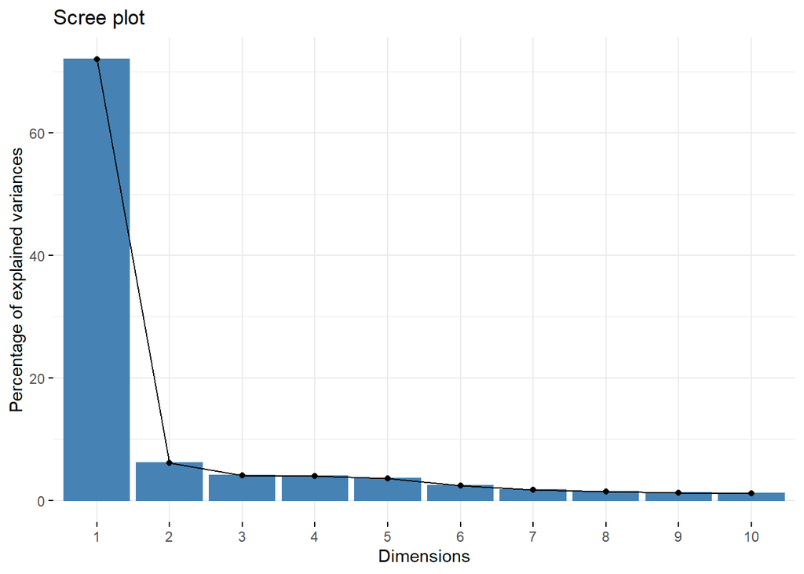

```r
fviz_screeplot(res.pca, ncp=10)
```

D’aprés ce critere on va retenir les 2 premiers axes puisque le coude se trouve au niveau de deuxieme axe

En faisant une sorte de vote sur les trois criteres,on doit retenir les 2 premiers axes

### 12-Interpretation de la cartes des variables :

```r
names(res.pca$var)
```

```
## [1] "coord"   "cor"     "cos2"    "contrib"
```

### 13-Coordonnee des variables :

```r
res.pca$var$coord
```

```
##                                        Dim.1       Dim.2         Dim.3
## Le.plaisir                         0.8645927 -0.25454795  0.0005163246
## Defoulement                        0.8972755 -0.06383339 -0.1587775214
## Entretenir.le.corps                0.8559056 -0.11084246  0.0698797413
## Prendre.la.masse.musculaire        0.7543529  0.13407403  0.5755896713
## Perdre.le.poids                    0.6547463  0.58856056 -0.3268595907
## Avoir.une.bonne.condition.physique 0.9213084  0.02151688 -0.0430369152
## Avoir.plus.d.energie               0.9187486 -0.16227494 -0.0631465192
## Rencontrer.de.nouvelles.personnes  0.7293612 -0.36318649  0.0627062785
## Equilibre.de.vie                   0.9074286 -0.11574533 -0.0558777524
## Mental.clair.et.serein             0.8713960 -0.05836209 -0.1432184051
## Developper.la.souplesse            0.7903583  0.35830455  0.1156685434
## Réduire.le.stress                  0.9362174 -0.01605574 -0.0894619628
## Eviter.la.routine                  0.9304806 -0.08230604 -0.0836687845
## Confiance                          0.7942191  0.30747737  0.2010108707
##                                          Dim.4        Dim.5
## Le.plaisir                         -0.07594046  0.094012636
## Defoulement                        -0.17240815 -0.090217626
## Entretenir.le.corps                -0.39971295 -0.001200829
## Prendre.la.masse.musculaire        -0.17011721  0.039224865
## Perdre.le.poids                    -0.10661238  0.254608981
## Avoir.une.bonne.condition.physique -0.14948044  0.016231269
## Avoir.plus.d.energie               -0.06909797  0.083959008
## Rencontrer.de.nouvelles.personnes   0.31655748  0.423548977
## Equilibre.de.vie                    0.18935141 -0.172433779
## Mental.clair.et.serein              0.20238454 -0.233488850
## Developper.la.souplesse             0.22995432  0.209389210
## Réduire.le.stress                  -0.02458989 -0.087394845
## Eviter.la.routine                   0.04044609 -0.099510724
## Confiance                           0.23467278 -0.286767720
```

### 14-cos2 des variables :

```r
res.pca$var$cos2
```

```
##                                        Dim.1        Dim.2        Dim.3
## Le.plaisir                         0.7475205 0.0647946589 2.665911e-07
## Defoulement                        0.8051033 0.0040747015 2.521030e-02
## Entretenir.le.corps                0.7325744 0.0122860517 4.883178e-03
## Prendre.la.masse.musculaire        0.5690482 0.0179758458 3.313035e-01
## Perdre.le.poids                    0.4286928 0.3464035323 1.068372e-01
## Avoir.une.bonne.condition.physique 0.8488091 0.0004629763 1.852176e-03
## Avoir.plus.d.energie               0.8440989 0.0263331561 3.987483e-03
## Rencontrer.de.nouvelles.personnes  0.5319678 0.1319044244 3.932077e-03
## Equilibre.de.vie                   0.8234266 0.0133969804 3.122323e-03
## Mental.clair.et.serein             0.7593309 0.0034061332 2.051151e-02
## Developper.la.souplesse            0.6246662 0.1283821530 1.337921e-02
## Réduire.le.stress                  0.8765029 0.0002577867 8.003443e-03
## Eviter.la.routine                  0.8657942 0.0067742837 7.000465e-03
## Confiance                          0.6307841 0.0945423324 4.040537e-02
##                                           Dim.4        Dim.5
## Le.plaisir                         0.0057669528 8.838376e-03
## Defoulement                        0.0297245701 8.139220e-03
## Entretenir.le.corps                0.1597704408 1.441990e-06
## Prendre.la.masse.musculaire        0.0289398664 1.538590e-03
## Perdre.le.poids                    0.0113662003 6.482573e-02
## Avoir.une.bonne.condition.physique 0.0223444031 2.634541e-04
## Avoir.plus.d.energie               0.0047745300 7.049115e-03
## Rencontrer.de.nouvelles.personnes  0.1002086399 1.793937e-01
## Equilibre.de.vie                   0.0358539573 2.973341e-02
## Mental.clair.et.serein             0.0409595011 5.451704e-02
## Developper.la.souplesse            0.0528789906 4.384384e-02
## Réduire.le.stress                  0.0006046626 7.637859e-03
## Eviter.la.routine                  0.0016358859 9.902384e-03
## Confiance                          0.0550713141 8.223572e-02
```

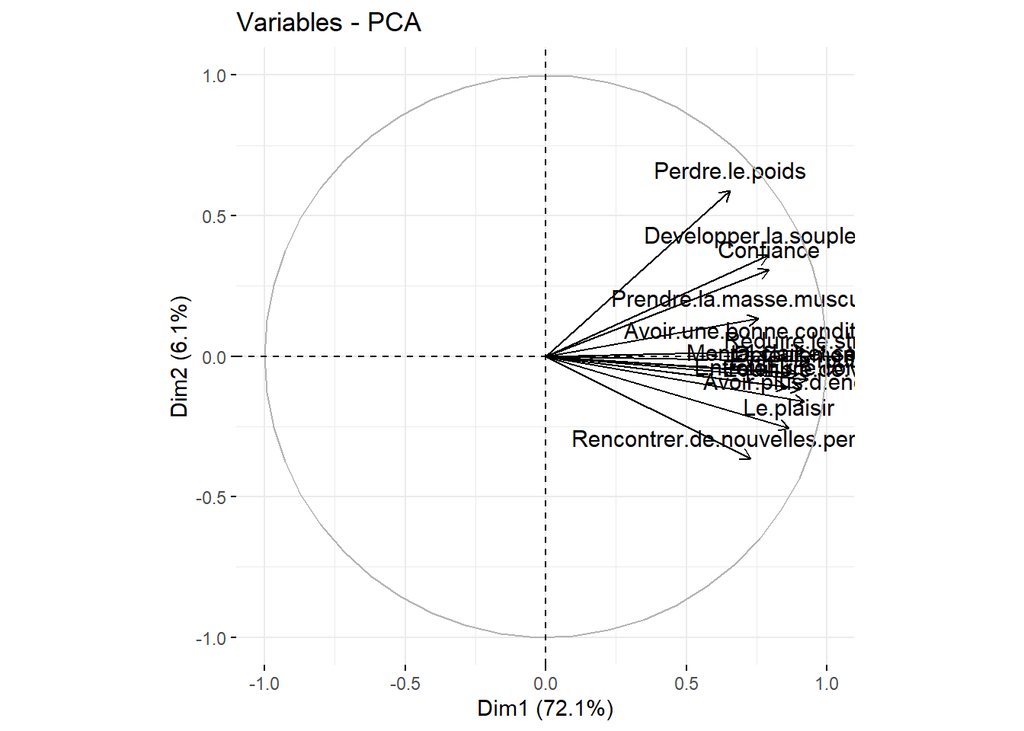

```r
fviz_pca_var(res.pca)
```

Presque toutes les variables telles que “Plaisir”,“Defoulement”, “Perdre le poids”,“Entretenir le corps”,“Avoir plus d’energie”, “Equilibre de vie”,“Reduire le stress”,“Eviter la routine”,“confiance”, …..,sont corrolées positvement avec le premier axe . Si on devait donner un nom a cet axe ca serait l’axe de “Motivation”.

Les variables “perdre le poids” et “Developper la souplesse” sont un peu fortement corrolées avec le deuxieme axes qu’on peut l’appeler axe de “Agilité”.

Le deuxieme axe (“Agilité”) oppose la variable “Perdre le poids” a la variable “Rencontrer de nouvelles personnes”.

Donc un individu qui cherche d’avoir des nouvelles relation , il y a une forte probabilité qu’il ne cherche pas d’etre agile .

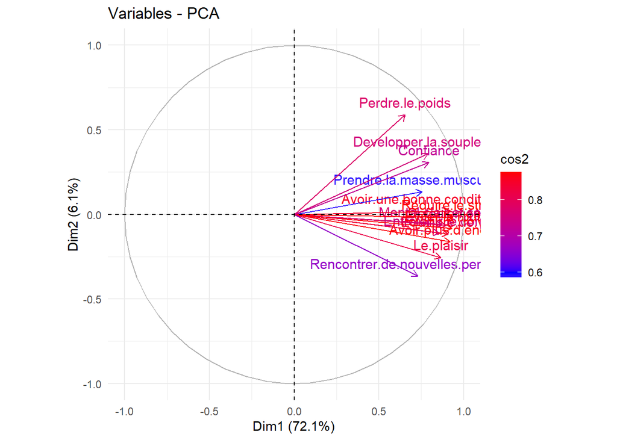

```r
fviz_pca_var(res.pca, col.var="cos2") +
  scale_color_gradient2(low="white", mid="blue",
                        high="red", midpoint=0.6) +
  theme_minimal()
```

Notons que la qualité de représentation d’une variable sur le premier plan est donnée par la somme de ses cos2 sur chacun des 2 premiers axes.

### 15-Carte des individus:

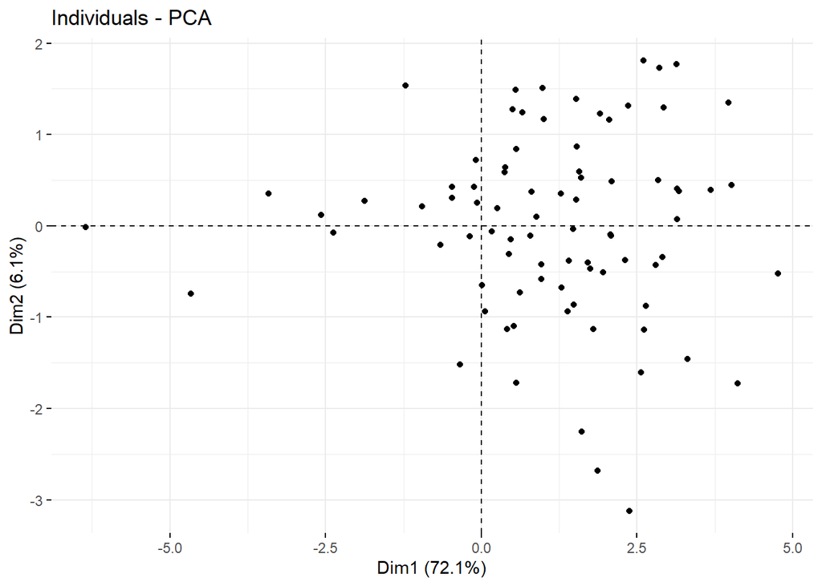

```r
fviz_pca_ind(res.pca,geom = "point",col.ind.sup = 'gray')
```

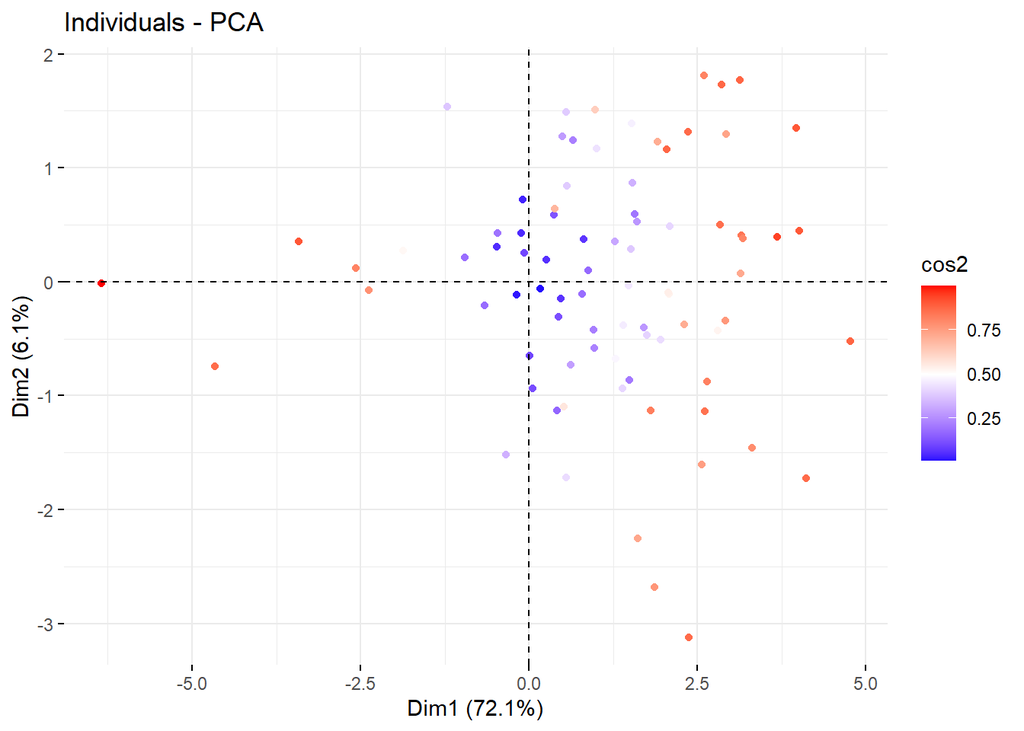

```r
fviz_pca_ind(res.pca,geom = "point",col.ind="cos2")+
  scale_color_gradient2(low="blue", mid="white",
                        high="red", midpoint=0.5)
```

Notons que la qualité de représentation d’un individu sur le premier plan est donnée par la somme de ses cos2 sur chacun des 2 premiers axes.

### 16-Croissement avec la variable sexe :

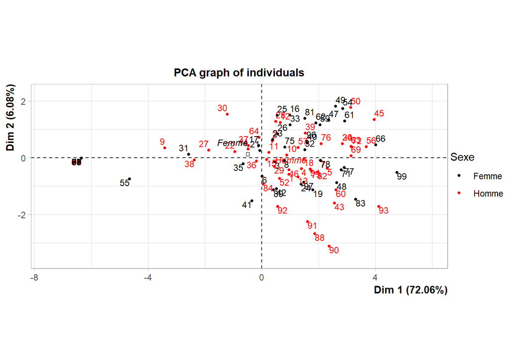

```r
plot.PCA(res.pca, axes=c(1, 2), choix="ind", habillage=1, cex=0.8)
```

Les deux catégories sexuelles ont presque des coordonnées egales sur le premier axes sauf qu’il y a condensation importante des Hommes que des Femmes sur la partie droite de l’axe ce qui explique que les Hommes sont plus motivés que les Femmes

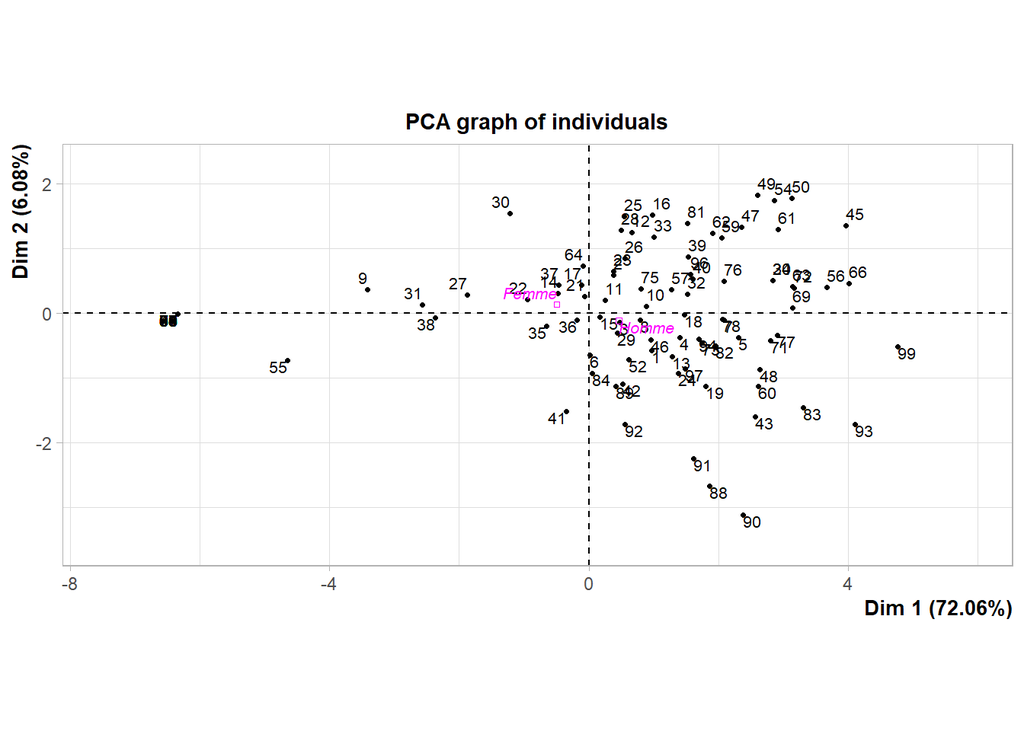

```r
plot(res.pca, choix="ind", cex=0.7)
```

Meme conclusion en se basant sur les position des modalites de la variable qualitative “sexe”: Homme légerment a droite de l’axe 1 par rapport a la modalité Femme ’.

### 17-Croissement avec la variable CSP:

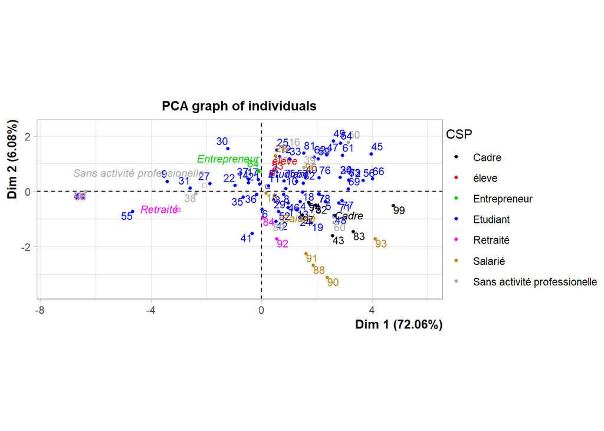

```r
plot.PCA(res.pca2, axes=c(1, 2), choix="ind", habillage=1, cex=0.8)
```

Les cadres,les etudiants les salariés sont les catégories les plus motivés . De plus les cadres et les salariés cherche d’avoir des nouvelles amis alors que les etudiants cherche d’etre agile et souple. Les retraités et ceux qui n’ont pas d’activité professionelle sont plutot non motivés

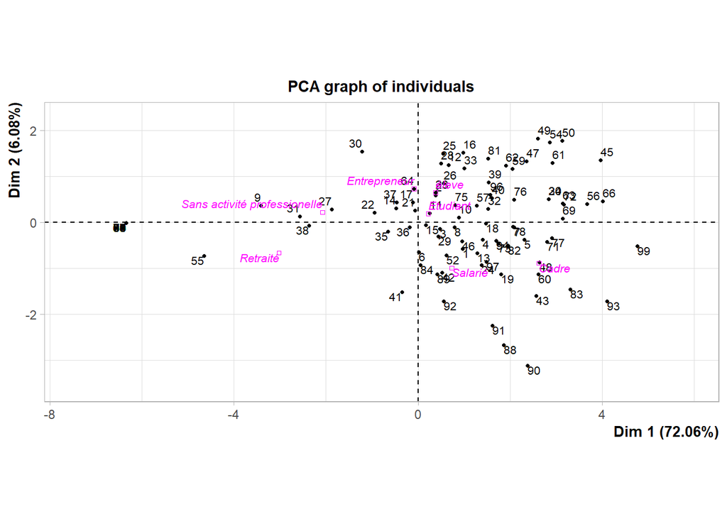

```r
plot(res.pca2, choix="ind", cex=0.7)
```

# Analyse Factorielle des correspondances sur les variables “CSP” et “Budget mensuelle”:"

```r
tab1<-table(data$CSP,data$Budget.mensuel)
tab1
```

```
##
##                                Entre 20 et 50 dt Entre 50 et 100 dt
##   Cadre                                        1                  2
##   éleve                                        1                  0
##   Entrepreneur                                 0                  0
##   Etudiant                                    43                 15
##   Retraité                                     1                  1
##   Salarié                                      1                  4
##   Sans activité professionelle                 3                  3
##
##                                Moins de 20 dt Plus de 100 dt
##   Cadre                                     1              2
##   éleve                                     0              0
##   Entrepreneur                              1              0
##   Etudiant                                  5              4
##   Retraité                                  2              0
##   Salarié                                   2              1
##   Sans activité professionelle              5              1
```

```r
addmargins(tab1)
```

```
##
##                                Entre 20 et 50 dt Entre 50 et 100 dt
##   Cadre                                        1                  2
##   éleve                                        1                  0
##   Entrepreneur                                 0                  0
##   Etudiant                                    43                 15
##   Retraité                                     1                  1
##   Salarié                                      1                  4
##   Sans activité professionelle                 3                  3
##   Sum                                         50                 25
##
##                                Moins de 20 dt Plus de 100 dt Sum
##   Cadre                                     1              2   6
##   éleve                                     0              0   1
##   Entrepreneur                              1              0   1
##   Etudiant                                  5              4  67
##   Retraité                                  2              0   4
##   Salarié                                   2              1   8
##   Sans activité professionelle              5              1  12
##   Sum                                      16              8  99
```

```r
prop.table(tab1)
```

```
##
##                                Entre 20 et 50 dt Entre 50 et 100 dt
##   Cadre                               0.01010101         0.02020202
##   éleve                               0.01010101         0.00000000
##   Entrepreneur                        0.00000000         0.00000000
##   Etudiant                            0.43434343         0.15151515
##   Retraité                            0.01010101         0.01010101
##   Salarié                             0.01010101         0.04040404
##   Sans activité professionelle        0.03030303         0.03030303
##
##                                Moins de 20 dt Plus de 100 dt
##   Cadre                            0.01010101     0.02020202
##   éleve                            0.00000000     0.00000000
##   Entrepreneur                     0.01010101     0.00000000
##   Etudiant                         0.05050505     0.04040404
##   Retraité                         0.02020202     0.00000000
##   Salarié                          0.02020202     0.01010101
##   Sans activité professionelle     0.05050505     0.01010101
```

```r
addmargins(prop.table(tab1))
```

```
##
##                                Entre 20 et 50 dt Entre 50 et 100 dt
##   Cadre                               0.01010101         0.02020202
##   éleve                               0.01010101         0.00000000
##   Entrepreneur                        0.00000000         0.00000000
##   Etudiant                            0.43434343         0.15151515
##   Retraité                            0.01010101         0.01010101
##   Salarié                             0.01010101         0.04040404
##   Sans activité professionelle        0.03030303         0.03030303
##   Sum                                 0.50505051         0.25252525
##
##                                Moins de 20 dt Plus de 100 dt        Sum
##   Cadre                            0.01010101     0.02020202 0.06060606
##   éleve                            0.00000000     0.00000000 0.01010101
##   Entrepreneur                     0.01010101     0.00000000 0.01010101
##   Etudiant                         0.05050505     0.04040404 0.67676768
##   Retraité                         0.02020202     0.00000000 0.04040404
##   Salarié                          0.02020202     0.01010101 0.08080808
##   Sans activité professionelle     0.05050505     0.01010101 0.12121212
##   Sum                              0.16161616     0.08080808 1.00000000
```

```r
f<-round(100*tab1/sum(tab1),1)
f
```

```
##
##                                Entre 20 et 50 dt Entre 50 et 100 dt
##   Cadre                                      1.0                2.0
##   éleve                                      1.0                0.0
##   Entrepreneur                               0.0                0.0
##   Etudiant                                  43.4               15.2
##   Retraité                                   1.0                1.0
##   Salarié                                    1.0                4.0
##   Sans activité professionelle               3.0                3.0
##
##                                Moins de 20 dt Plus de 100 dt
##   Cadre                                   1.0            2.0
##   éleve                                   0.0            0.0
##   Entrepreneur                            1.0            0.0
##   Etudiant                                5.1            4.0
##   Retraité                                2.0            0.0
##   Salarié                                 2.0            1.0
##   Sans activité professionelle            5.1            1.0
```

### Detemination de profil ligne et de profil colonne :

```r
prof_lig<-addmargins(prop.table(addmargins(tab1,1),1),2)
prof_lig
```

```
##
##                                Entre 20 et 50 dt Entre 50 et 100 dt
##   Cadre                               0.16666667         0.33333333
##   éleve                               1.00000000         0.00000000
##   Entrepreneur                        0.00000000         0.00000000
##   Etudiant                            0.64179104         0.22388060
##   Retraité                            0.25000000         0.25000000
##   Salarié                             0.12500000         0.50000000
##   Sans activité professionelle        0.25000000         0.25000000
##   Sum                                 0.50505051         0.25252525
##
##                                Moins de 20 dt Plus de 100 dt        Sum
##   Cadre                            0.16666667     0.33333333 1.00000000
##   éleve                            0.00000000     0.00000000 1.00000000
##   Entrepreneur                     1.00000000     0.00000000 1.00000000
##   Etudiant                         0.07462687     0.05970149 1.00000000
##   Retraité                         0.50000000     0.00000000 1.00000000
##   Salarié                          0.25000000     0.12500000 1.00000000
##   Sans activité professionelle     0.41666667     0.08333333 1.00000000
##   Sum                              0.16161616     0.08080808 1.00000000
```

```r
prof_col<-addmargins(prop.table(addmargins(tab1,2),2),1)
prof_col
```

```
##
##                                Entre 20 et 50 dt Entre 50 et 100 dt
##   Cadre                               0.02000000         0.08000000
##   éleve                               0.02000000         0.00000000
##   Entrepreneur                        0.00000000         0.00000000
##   Etudiant                            0.86000000         0.60000000
##   Retraité                            0.02000000         0.04000000
##   Salarié                             0.02000000         0.16000000
##   Sans activité professionelle        0.06000000         0.12000000
##   Sum                                 1.00000000         1.00000000
##
##                                Moins de 20 dt Plus de 100 dt        Sum
##   Cadre                            0.06250000     0.25000000 0.06060606
##   éleve                            0.00000000     0.00000000 0.01010101
##   Entrepreneur                     0.06250000     0.00000000 0.01010101
##   Etudiant                         0.31250000     0.50000000 0.67676768
##   Retraité                         0.12500000     0.00000000 0.04040404
##   Salarié                          0.12500000     0.12500000 0.08080808
##   Sans activité professionelle     0.31250000     0.12500000 0.12121212
##   Sum                              1.00000000     1.00000000 1.00000000
```

```r
library(questionr)
lprop(tab1)
```

```
##
##                                Entre 20 et 50 dt Entre 50 et 100 dt
##   Cadre                         16.7              33.3
##   éleve                        100.0               0.0
##   Entrepreneur                   0.0               0.0
##   Etudiant                      64.2              22.4
##   Retraité                      25.0              25.0
##   Salarié                       12.5              50.0
##   Sans activité professionelle  25.0              25.0
##   All                           50.5              25.3
##
##                                Moins de 20 dt Plus de 100 dt Total
##   Cadre                         16.7           33.3          100.0
##   éleve                          0.0            0.0          100.0
##   Entrepreneur                 100.0            0.0          100.0
##   Etudiant                       7.5            6.0          100.0
##   Retraité                      50.0            0.0          100.0
##   Salarié                       25.0           12.5          100.0
##   Sans activité professionelle  41.7            8.3          100.0
##   All                           16.2            8.1          100.0
```

Parmi les etudiants , 64.2% investissent entre 20 et 50 dt , 22.4% entre 50 et 100dt , 7.5% investissent moins de 20dt , 6% plus de 100dt

```r
cprop(tab1)
```

```
##
##                                Entre 20 et 50 dt Entre 50 et 100 dt
##   Cadre                          2.0               8.0
##   éleve                          2.0               0.0
##   Entrepreneur                   0.0               0.0
##   Etudiant                      86.0              60.0
##   Retraité                       2.0               4.0
##   Salarié                        2.0              16.0
##   Sans activité professionelle   6.0              12.0
##   Total                        100.0             100.0
##
##                                Moins de 20 dt Plus de 100 dt All
##   Cadre                          6.2           25.0            6.1
##   éleve                          0.0            0.0            1.0
##   Entrepreneur                   6.2            0.0            1.0
##   Etudiant                      31.2           50.0           67.7
##   Retraité                      12.5            0.0            4.0
##   Salarié                       12.5           12.5            8.1
##   Sans activité professionelle  31.2           12.5           12.1
##   Total                        100.0          100.0          100.0
```

Parmi ceux qui investissent plus de 100 dt dans le sport , 25% sont des cadres , 50% sont des etudiants , 12.5% sont des salariés , 12.5% sont ceux qui n’ont pas d’activité professionnelles

### Test de Khi-deux:

On va calculer le test de Khi-deux pour savoir est ce que l’ AFC est pertinente ou non pour ces variables choisies

```r
test<-chisq.test(tab1)
test
```

```
##
##  Pearson's Chi-squared test
##
## data:  tab1
## X-squared = 33.481, df = 18, p-value = 0.01459
```

La valeur de $\chi^2$ est egale a 33.481 Le degré de liberté du $\chi^2$ est de $(p-1)*(q-1)=(7-1)(4-1)=18$ La p-value étant inférieur a 5% ,donc on peut donc rejeter l’hypothese d’indépendance : l’AFC est donc pertinente !

### Exécution de l’AFC:

```r
res.ca<-CA(tab1,graph=F)
summary(res.ca)
```

```
##
## Call:
## CA(X = tab1, graph = F)
##
## The chi square of independence between the two variables is equal to 33.48084 (p-value =  0.01458793 ).
##
## Eigenvalues
##                        Dim.1   Dim.2   Dim.3
## Variance               0.234   0.085   0.019
## % of var.             69.186  25.153   5.661
## Cumulative % of var.  69.186  94.339 100.000
##
## Rows
##                                Iner*1000    Dim.1    ctr   cos2    Dim.2    ctr
## Cadre                        |    63.144 |  0.450  5.237  0.194 |  0.862 52.948
## éleve                        |     9.899 | -0.841  3.056  0.722 | -0.440  2.294
## Entrepreneur                 |    52.399 |  1.927 16.032  0.716 | -1.129 15.146
## Etudiant                     |    62.673 | -0.302 26.350  0.984 | -0.039  1.198
## Retraité                     |    37.096 |  0.824 11.713  0.739 | -0.482 11.044
## Salarié                      |    48.567 |  0.583 11.738  0.565 |  0.373 13.188
## Sans activité professionelle |    64.413 |  0.707 25.874  0.940 | -0.171  4.182
##                                cos2    Dim.3    ctr   cos2
## Cadre                         0.713 |  0.311 30.552  0.093 |
## éleve                         0.197 |  0.281  4.161  0.080 |
## Entrepreneur                  0.246 |  0.445 10.466  0.038 |
## Etudiant                      0.016 | -0.001  0.003  0.000 |
## Retraité                      0.253 | -0.085  1.536  0.008 |
## Salarié                       0.231 | -0.350 51.632  0.204 |
## Sans activité professionelle  0.055 |  0.051  1.650  0.005 |
##
## Columns
##                                Iner*1000     Dim.1     ctr    cos2     Dim.2
## Entre 20 et 50 dt            |    92.723 |  -0.407  35.756   0.902 |  -0.128
## Entre 50 et 100 dt           |    28.470 |   0.136   2.003   0.165 |   0.224
## Moins de 20 dt               |   158.580 |   0.932  60.018   0.886 |  -0.329
## Plus de 100 dt               |    58.418 |   0.254   2.223   0.089 |   0.759
##                                  ctr    cos2     Dim.3     ctr    cos2
## Entre 20 et 50 dt              9.756   0.090 |   0.039   3.983   0.008 |
## Entre 50 et 100 dt            14.951   0.447 |  -0.209  57.793   0.389 |
## Moins de 20 dt                20.614   0.111 |   0.062   3.206   0.004 |
## Plus de 100 dt                54.679   0.796 |   0.288  35.018   0.115 |
```

### Coix de nombre d’axe a retenir:

```r
eig.val <- res.ca$eig
round(res.ca$eig,3)
```

```
##       eigenvalue percentage of variance cumulative percentage of variance
## dim 1      0.234                 69.186                            69.186
## dim 2      0.085                 25.153                            94.339
## dim 3      0.019                  5.661                           100.000
```

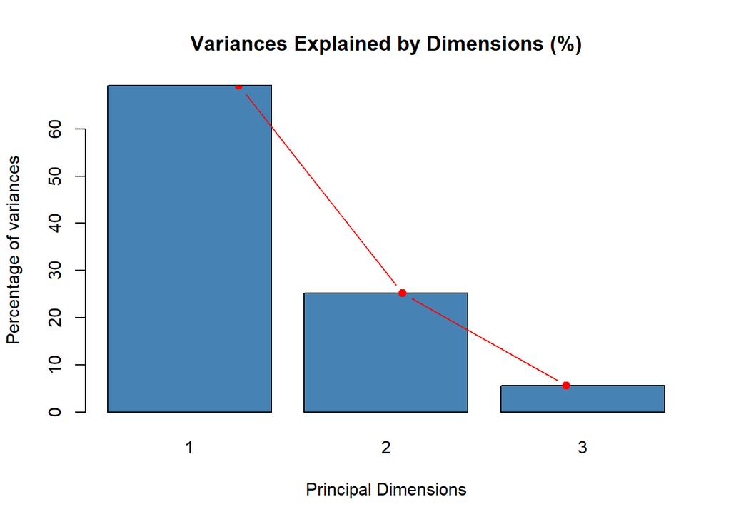

```r
barplot(eig.val[, 2],
        names.arg = 1:nrow(eig.val),
        main = "Variances Explained by Dimensions (%)",
        xlab = "Principal Dimensions",
        ylab = "Percentage of variances",
        col ="steelblue")

lines(x = 1:nrow(eig.val), eig.val[, 2],
      type = "b", pch = 19, col = "red")
```

Les deux premiers axes portent plus de 94% de l’information totale’, donc d’apres le critere de taux d’inertie cumule il est clair qu’on va retenir ces deux axes. ’

### Représentation et interprétation de la carte des profils-colonnes:

```r
round(cbind(res.ca$col$coord[,1:2],res.ca$col$contrib[,1:2], res.ca$col$cos2[,1:2]),2)
```

```
##                    Dim 1 Dim 2 Dim 1 Dim 2 Dim 1 Dim 2
## Entre 20 et 50 dt  -0.41 -0.13 35.76  9.76  0.90  0.09
## Entre 50 et 100 dt  0.14  0.22  2.00 14.95  0.16  0.45
## Moins de 20 dt      0.93 -0.33 60.02 20.61  0.89  0.11
## Plus de 100 dt      0.25  0.76  2.22 54.68  0.09  0.80
```

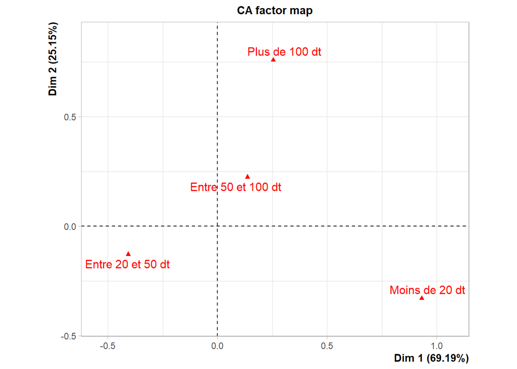

```r
plot(res.ca, invisible="row")
```

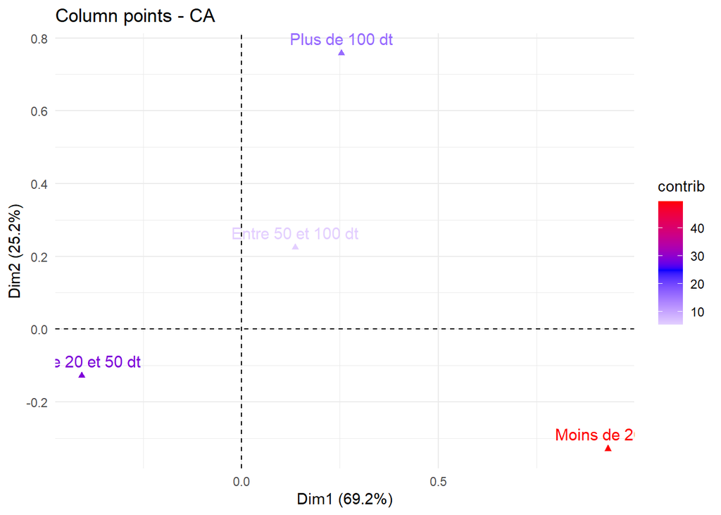

```r
# Carte qui permet de controler automatiquement la couleur selon la contribution

fviz_ca_col(res.ca, col.col = "contrib")+
  scale_color_gradient2(low = "white", mid = "blue",
                        high = "red", midpoint = 25) +
  theme_minimal()
```

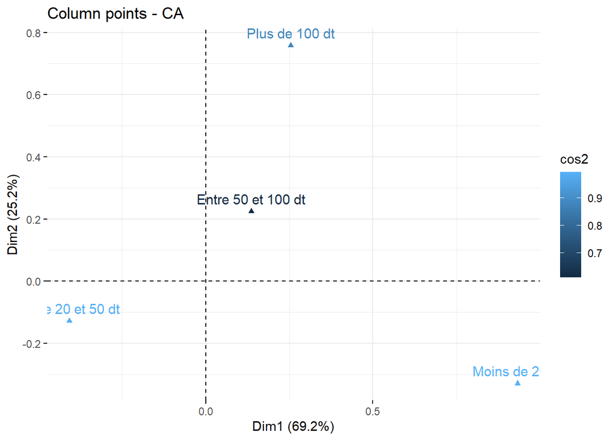

```r
# Carte qui permet de controler automatiquement la couleur selon le cos2

fviz_ca_col(res.ca, col.col="cos2")
```

### Représentation et interprétation de la carte des profils-lignes:

```r
round(cbind(res.ca$row$coord[,1:2],res.ca$row$contrib[,1:2], res.ca$row$cos2[,1:2]),2)
```

```
##                              Dim 1 Dim 2 Dim 1 Dim 2 Dim 1 Dim 2
## Cadre                         0.45  0.86  5.24 52.95  0.19  0.71
## éleve                        -0.84 -0.44  3.06  2.29  0.72  0.20
## Entrepreneur                  1.93 -1.13 16.03 15.15  0.72  0.25
## Etudiant                     -0.30 -0.04 26.35  1.20  0.98  0.02
## Retraité                      0.82 -0.48 11.71 11.04  0.74  0.25
## Salarié                       0.58  0.37 11.74 13.19  0.57  0.23
## Sans activité professionelle  0.71 -0.17 25.87  4.18  0.94  0.06
```

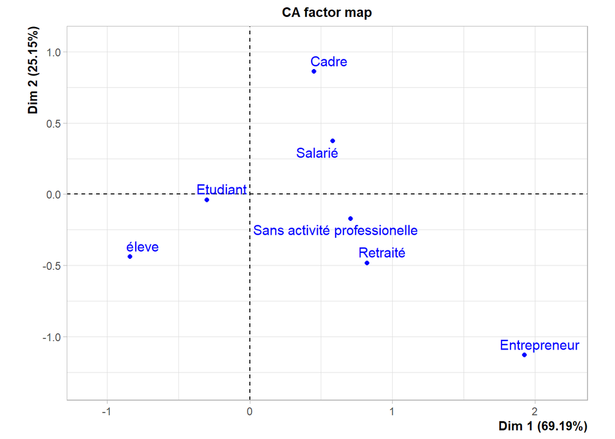

```r
plot(res.ca, invisible="col")
```

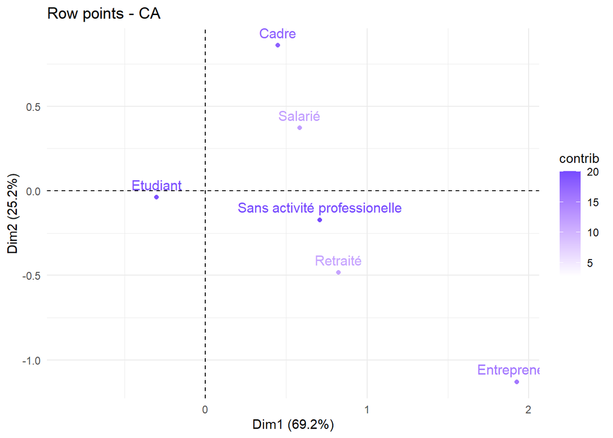

```r
# Carte qui permet de controler automatiquement la couleur selon la contribution

fviz_ca_row(res.ca, col.row = "contrib")+
  scale_color_gradient2(low = "white", mid = "blue",
                        high = "red", midpoint = 25) +
  theme_minimal()
```

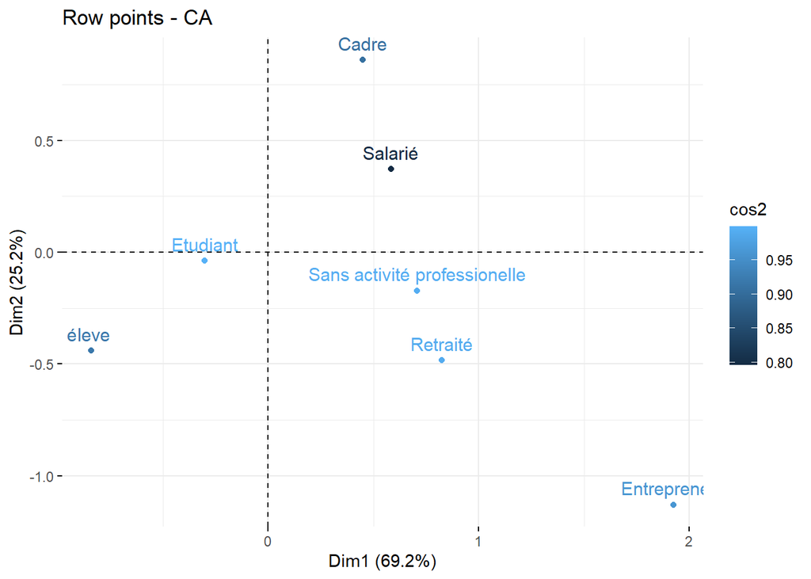

```r
# Carte qui permet de controler automatiquement la couleur selon le cos2

fviz_ca_row(res.ca, col.row = "cos2")
```

Le premier plan oppose eleve a entrepneur. Le deuxieme plan oppose Cadre a entrepreneur. Salarie a des faibles contributions(11.7% et 13.18%) et un cos moyennement important (0.79)

### Carte de représentation simultannée:

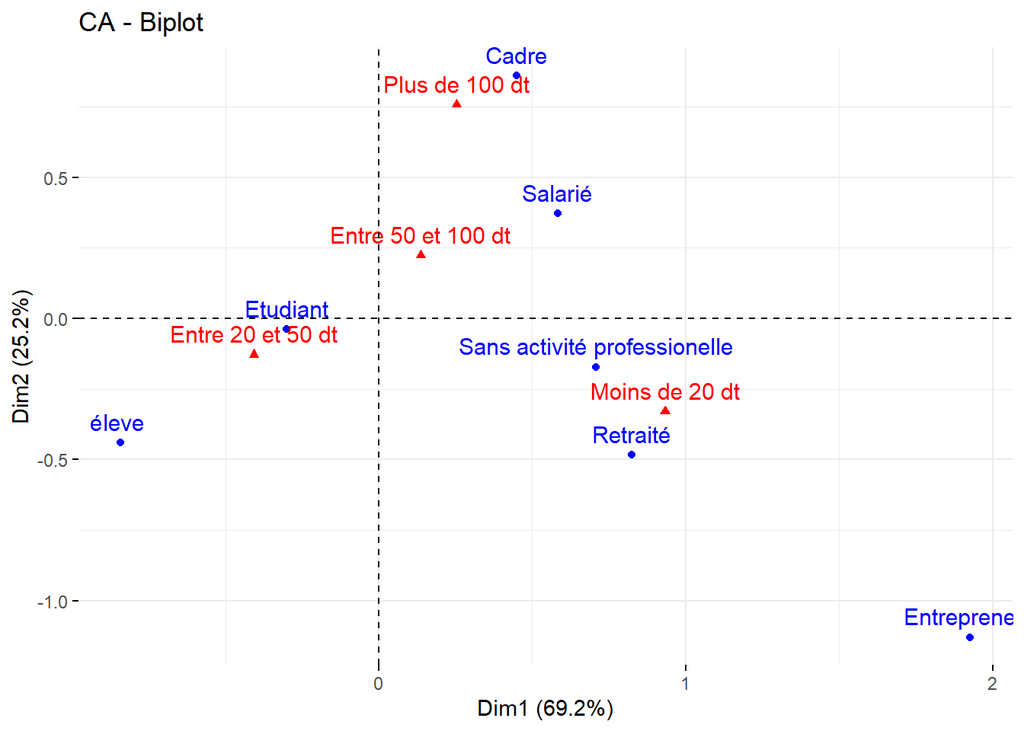

```r
# Biplot symétrique des lignes et des colonnes
fviz_ca_biplot(res.ca)
```

La carte de représentation simultannée montre une correpondance entre les modalités cadre et Plus de 100dt , etudiant et Entre 20 et 50dt, Sans activite professionnelle et Moins de 20dt , Salarie et Entre 50 et 100dt .

Les modalites “Entre 20 et 50dt” et “Entre 50 et 100dt” ont des positions centrales ceci est du au fait que presque tous les CSP peuvent investir entre 20 et 100dt dans le domaine sportif comme le montre le tableau de profil ligne :64.2% et 22.4% pour les etudiant et 12.5% et 50% pour les salarie.

Le lien entre Retraite et “Moins de 20dt” n’est pas symetrique ‘.En fait d’apres le tableau profil ligne , 50% des Retraite investissent moins de 20dt tandis que dans la modalite “Moins de 20dt” on trouve 31.2% sont des etudiants , 12.5% sont des retraite.’